# Homework #2

Robert Hereth

09/10/2021

# Problem 1

## Problem Statement

Using the `babynames` dataset, create a plot using data wrangling and `ggplot` to show the popularity of names within a group of people (family, friends, etc.).

## Solution

The graph pictured below depicts the popularity of the names within my immediate family: Robert, Andrew, Charles (the 3 kids), Mark (my father), and Jill (my mother). I also cut the data before 1955 as my name was fairly popular and created a rather uninteresting graph due to the scaling.

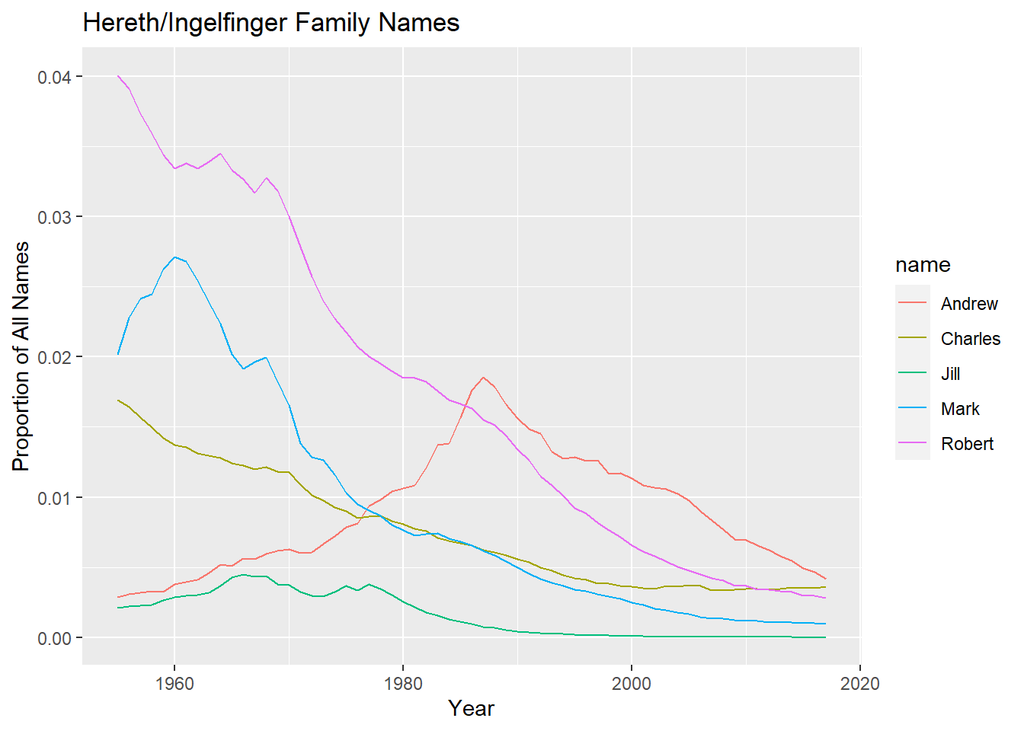

```r
library(tidyverse)
library(mdsr)
library(dplyr)

babyNames <- babynames::babynames
coolBabys <- babyNames %>%
  filter((name=="Robert" & sex=="M") |
         (name=="Mark" & sex=="M") |
         (name=="Charles" & sex=="M") |
         (name=="Andrew" & sex=="M") |
         (name=="Jill" & sex=="F"),
         year>=1955)
ggplot(coolBabys, aes(year, prop, color=name)) +
  geom_line() +
  labs(x="Year", y="Proportion of All Names",
       title="Hereth/Ingelfinger Family Names")
```

# Problem 2

## Problem Statement

Using the `Violations` dataset, look at the health violations for various zipcodes within Manhattan and create a plot that compares median inspection scores between zipcodes with “many” violations (50+) and “few” violations (less than 50).

## Solution

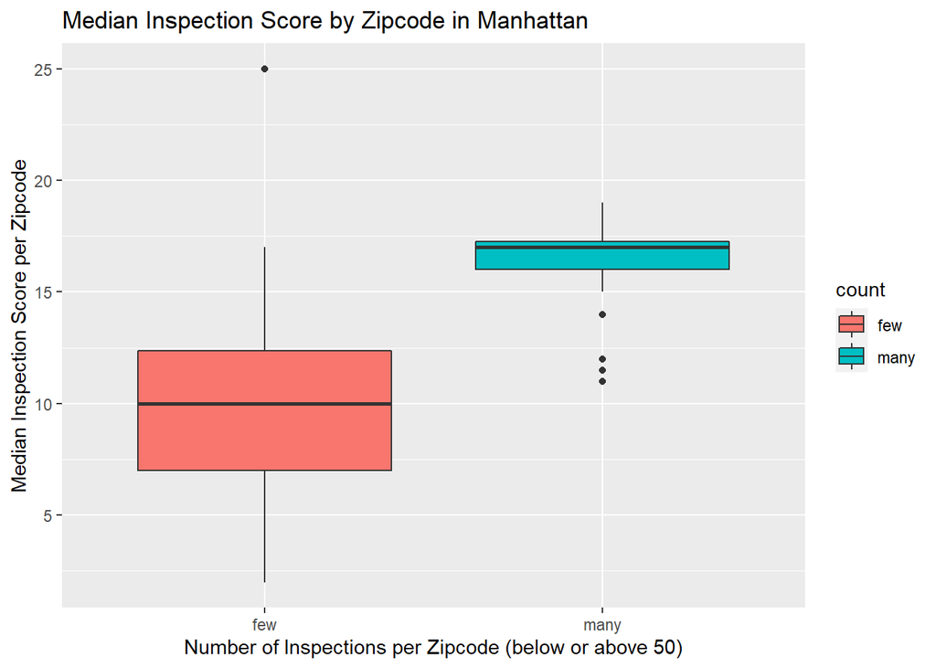

```r
library(tidyverse)
library(mdsr)
library(dplyr)

vio <- Violations
modVio <- vio %>%
  filter(boro=="MANHATTAN") %>%
  group_by(zipcode) %>%
  summarize(
    numCount=n(),
    medianScore = median(score, na.rm=T)) %>%
  mutate(count = ifelse(numCount>=50, "many", "few"))
boxScores <- ggplot(modVio, aes(count, medianScore, fill=count)) +
  geom_boxplot() +
  labs(x="Number of Inspections per Zipcode (below or above 50)",
       y="Median Inspection Score per Zipcode",
       title="Median Inspection Score by Zipcode in Manhattan")
pointScores <- ggplot(modVio, aes(medianScore, numCount, color=count)) +
  geom_point() +
  geom_smooth(method=lm, se=F) +
  facet_wrap(vars(count), scales="free") +
  labs(x="Median Inspection Score",
       y="Number of Inspections per Zipcode",
       title="Median Inspection Scores in Manhattan Zipcodes")
boxScores
```

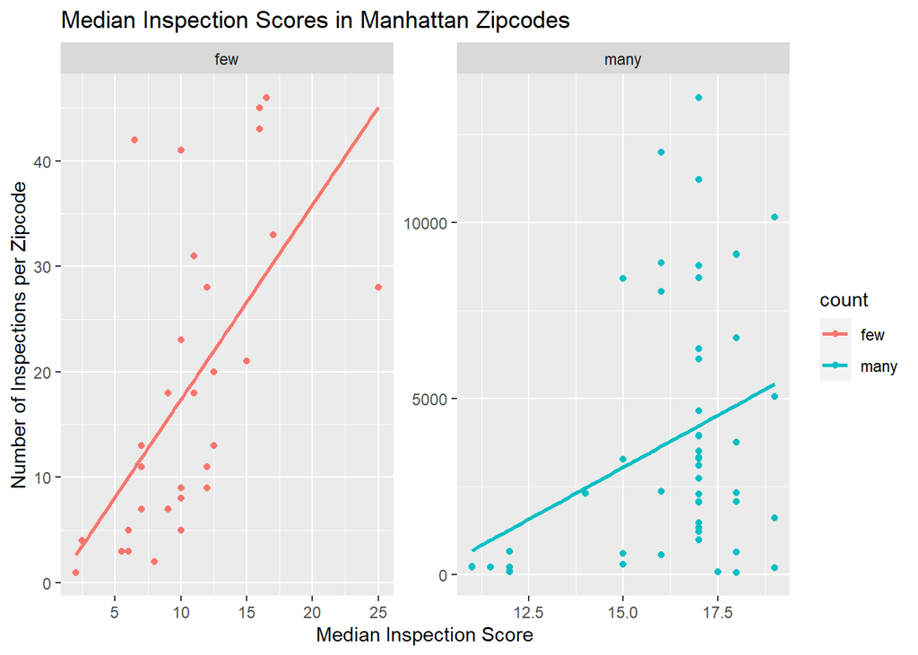

```r
pointScores
```

# Problem 3

## Problem Statement

Continuing off of the last problem, continue using `Violations` and use the `inner_join` command to join the `Violations`, `ViolationCodes` and `Cuisines` datasets in order to show the the number of critical violations within each distinct cuisine group.

## Solution

The output of the `head` command below shows the top six results of the set. There are a significantly higher number of “Critical” violations within American restraunts and eateries, most likely due to the significantly greater number of them within the Manhattan district. In addition, many American restraunts are franchised, meaning that they most likely have lower quality and sloppier practices in order to drive consumer costs down.

```r
library(tidyverse)
library(mdsr)
library(dplyr)

vios <- Violations
vioCodes <- ViolationCodes
combo <- inner_join(vios, vioCodes)
combo <- inner_join(combo, Cuisines)
numCritVio <- combo %>%
  filter(boro=="MANHATTAN", critical_flag=="Critical") %>%
  select(cuisine_description, critical_flag) %>%
  group_by(cuisine_description) %>%
  summarize(
    Count=n()
  ) %>%
  arrange(-Count)
head(numCritVio)
```

```
## # A tibble: 6 x 2
##   cuisine_description Count
##   <fct>               <int>
## 1 American            32187
## 2 Chinese              8129
## 3 Italian              7728
## 4 Japanese             5999
## 5 Cafe/Coffee/Tea      3971
## 6 Pizza                3946
```

# Problem 4

## Problem Statement

Using the `titanic` dataset, create two summaries: one showing the ages of female survivors and one showing the ages of male survivors.

## Solution

Overall, the sizes of the two datsasets seem to match the protocols followed during the wreck and sinking of the Titanic: “women and children first”. The female set has 197 survivors, whereas the male set has 93. In addition, the median ages of both sets was 28, with females having more middle-aged passengers and a smaller range of ages. The male set has a greater range with a smaller minimum age and a greater maximum age, though the quartile cutoffs were lower than the female set.

```r
library(tidyverse)
library(mdsr)
library(dplyr)
library(readr)

titanic <- read_csv("titanic.csv")
menAge <- titanic %>%
  filter(Sex=="male" & Survived==1 & Age!="NA") %>%
  select(Age)
femAge <- titanic %>%
  filter(Sex=="female" & Survived==1 & Age!="NA") %>%
  select(Age)
summary(femAge$Age)
```

```
##    Min. 1st Qu.  Median    Mean 3rd Qu.    Max.
##    0.75   19.00   28.00   28.85   38.00   63.00
```

```r
summary(menAge$Age)
```

```
##    Min. 1st Qu.  Median    Mean 3rd Qu.    Max.
##    0.42   18.00   28.00   27.28   36.00   80.00
```

# Problem 5

## Problem Statement

Returning to the `babynames` dataset, produce four lists focused around baby name popularity: two male and two female, with one of each being from all years and the other being from babys born after 2010.

## Solution

The four lists are seen below in the following order: male (all years), female (all years), male (past 2010), and female (past 2010). I’m glad to see my name as one of the top 3 all-time male names (even though this set only goes as far back as 1880)!

```r
library(tidyverse)
library(mdsr)
library(dplyr)
babynames <- babynames::babynames
menBaby <- babynames %>%
  filter(sex=="M") %>%
  select(name, n) %>%
  group_by(name) %>%
  summarize( count=sum(n) ) %>%
  arrange(-count)
femBaby <- babynames %>%
  filter(sex=="F") %>%
  select(name, n) %>%
  group_by(name) %>%
  summarize( count=sum(n) ) %>%
  arrange(-count)
menBabyAlpha <- babynames %>%
  filter(sex=="M" & year>2010) %>%
  select(name, n) %>%
  group_by(name) %>%
  summarize( count=sum(n) ) %>%
  arrange(-count)
femBabyAlpha <- babynames %>%
  filter(sex=="F" & year>2010) %>%
  select(name, n) %>%
  group_by(name) %>%
  summarize( count=sum(n) ) %>%
  arrange(-count)

head(menBaby, 10)
```

```
## # A tibble: 10 x 2
##    name      count
##    <chr>     <int>
##  1 James   5150472
##  2 John    5115466
##  3 Robert  4814815
##  4 Michael 4350824
##  5 William 4102604
##  6 David   3611329
##  7 Joseph  2603445
##  8 Richard 2563082
##  9 Charles 2386048
## 10 Thomas  2304948
```

```r
head(femBaby, 10)
```

```
## # A tibble: 10 x 2
##    name        count
##    <chr>       <int>
##  1 Mary      4123200
##  2 Elizabeth 1629679
##  3 Patricia  1571692
##  4 Jennifer  1466281
##  5 Linda     1452249
##  6 Barbara   1434060
##  7 Margaret  1246649
##  8 Susan     1121440
##  9 Dorothy   1107096
## 10 Sarah     1073895
```

```r
head(menBabyAlpha, 10)
```

```
## # A tibble: 10 x 2
##    name       count
##    <chr>      <int>
##  1 Noah      128748
##  2 Liam      122092
##  3 Mason     118693
##  4 Jacob     117974
##  5 William   114193
##  6 Ethan     107561
##  7 Michael   104923
##  8 Alexander 101624
##  9 James      98510
## 10 Elijah     96184
```

```r
head(femBabyAlpha, 10)
```

```
## # A tibble: 10 x 2
##    name       count
##    <chr>      <int>
##  1 Emma      141235
##  2 Sophia    132297
##  3 Olivia    130464
##  4 Isabella  119159
##  5 Ava       110508
##  6 Mia        92943
##  7 Emily      86146
##  8 Abigail    85113
##  9 Madison    71627
## 10 Charlotte  70674
```